# New Trial Design: Group sequential design using graphicalMCP and gsDesign2

## Overview

This document evaluates statistical significance for graphical multiplicity control with group sequential design following the Maurer-Bretz (2013) framework. The combination of graphicalMCP and gsDesign2 packages is used for design and analysis.

The trial tests 3 endpoints across 2 populations, yielding 6 hypotheses:

| Hypothesis | Endpoint | Population | Analyses |
| --- | --- | --- | --- |
| H1 | OS | BM+ | 3 |
| H2 | OS | Overall | 3 |
| H3 | PFS | BM+ | 2 |
| H4 | PFS | Overall | 2 |
| H5 | ORR | BM+ | 1 |
| H6 | ORR | Overall | 1 |

Key design features:

- Enrollment over 14 months with a 6-month ramp-up.
- BM+ prevalence assumed at 60%.

### Analysis timing rules

All timing is relative to final patient enrolled (FPE). Enrollment is planned over 14 months.

| Analysis | Timing rule (after FPE) | Max extension | Endpoints assessed |
| --- | --- | --- | --- |
| IA1 | 6 months after FPE | None | ORR (final for both populations), PFS and OS (interim) |
| IA2 | 14 months after FPE AND targeted PFS event count in BM+ reached | Up to 17 months after FPE (+3 months) | PFS (final for both populations), OS (interim) |
| Final | 24 months after FPE AND targeted OS event count in BM+ reached | Up to 30 months after FPE (+6 months) | OS (final for both populations) |

Notes on timing rules:

- IA1 is calendar-driven to ensure 6 months minimum follow-up for ORR assessment in all patients. PFS and OS are analyzed with whatever event counts are available at the cutoff.
- IA2 is both calendar- and event-driven: we require at least 14 months after FPE to ensure minimum follow-up of nearly 3x the assumed control median PFS, but also require the targeted BM+ PFS event count. If the targeted events are not reached by 14 months after FPE, the analysis may be delayed up to 3 months.
- The final analysis is event-driven for OS in BM+. If the targeted event count is not reached by 24 months after FPE, the analysis may be delayed up to 6 months (30 months after FPE).

## Design

```r
### THERE SHOULD BE NO NEED TO MODIFY THIS CODE SECTION
old <- options(scipen = 999)
cbPalette <- c("#999999", "#E69F00", "#56B4E9", "#009E73", "#F0E442", "#0072B2", "#D55E00", "#CC79A7")
library(dplyr)
library(tibble)
library(knitr)
library(kableExtra)
library(gt)
library(ggplot2)
library(gsDesign)
library(gsDesign2)
library(graphicalMCP)
library(simtrial)
library(survival)

if (!"sequential_pval" %in% getNamespaceExports("gsDesign2")) {
  stop(
    "This vignette requires a version of gsDesign2 that exports `sequential_pval()`.\n",
    "Install the GitHub version from `Merck/gsDesign2`."
  )
}
```

### Multiplicity diagram for hypothesis testing

Alpha is split equally between BM+ and Overall populations for OS, with smaller allocations to PFS and ORR. Reallocation flows from BM+ to Overall within each endpoint, and from Overall to the next endpoint’s populations.

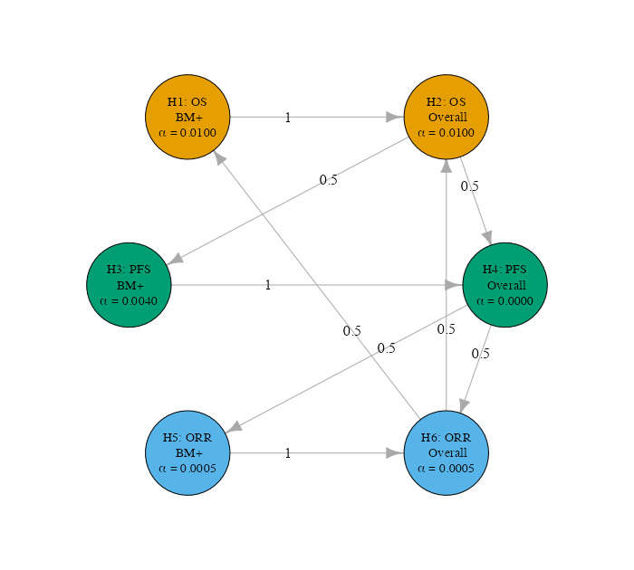

```r
### MODIFY HYPOTHESES, ALPHA, AND TRANSITIONS FOR YOUR STUDY
nameHypotheses <- c(
  "H1: OS\n BM+",
  "H2: OS\n Overall",
  "H3: PFS\n BM+",
  "H4: PFS\n Overall",
  "H5: ORR\n BM+",
  "H6: ORR\n Overall"
)
nHypotheses <- length(nameHypotheses)

# Transition weights for alpha reallocation
m <- matrix(c(
  0, 1, 0, 0, 0, 0,
  0, 0, .5, .5, 0, 0,
  0, 0, 0, 1, 0, 0,
  0, 0, 0, 0, .5, .5,
  0, 0, 0, 0, 0, 1,
  .5, .5, 0, 0, 0, 0
), nrow = 6, byrow = TRUE)

# Initial Type I error assigned to each hypothesis (one-sided)
alphaHypotheses <- c(.01, .01, .004, 0.000, 0.0005, .0005)
fwer <- sum(alphaHypotheses)

fill_idx <- c(2, 2, 4, 4, 3, 3)
vertex_color_map <- stats::setNames(cbPalette[fill_idx], nameHypotheses)

g0 <- graphicalMCP::graph_create(
  hypotheses = stats::setNames(alphaHypotheses / fwer, nameHypotheses),
  transitions = m,
  hyp_names = nameHypotheses
)

layout6 <- rbind(
  c(0.28, 0.74),
  c(0.72, 0.74),
  c(0.18, 0.50),
  c(0.82, 0.50),
  c(0.28, 0.26),
  c(0.72, 0.26)
)

# Build vertex labels with alpha character
alphaLabels <- sprintf("\u03b1 = %s", format(alphaHypotheses, scientific = FALSE))
vertexLabels <- paste(nameHypotheses, alphaLabels, sep = "\n")

plot(g0,
  layout = layout6,
  vertex.size = 45,
  vertex.label = vertexLabels,
  vertex.label.cex = 0.9,
  vertex.color = unname(vertex_color_map[names(g0$hypotheses)]),
  margin = 0.25
)
```

### Common design parameters

BM+ prevalence is 60%. Enrollment occurs over 14 months with a 6-month ramp-up.

```r
### MODIFY THESE PARAMETERS FOR YOUR STUDY
bm_prev <- 0.60
osmedian <- 12  # Control median OS (months)
pfsmedian <- 5  # Control median PFS (months)
```

### Group sequential designs for each hypothesis

H1 (OS in BM+) is the sample-size-driving hypothesis, designed with `gs_design_ahr()` targeting 90% power. All other hypotheses use the enrollment rates derived from H1 and compute power with `gs_power_ahr()` (time-to-event) or `fixed_design_rd()` (ORR).

#### H1: OS, BM+ (sample-size-driving)

BM+ subgroup only. Control median OS = 12 months, HR = 0.65. Target 90% power. This design determines the BM+ enrollment rate and sample size for all other hypotheses.

```r
fail_rate_os_sub <- gsDesign2::define_fail_rate(
  duration = Inf,
  fail_rate = log(2) / osmedian,
  hr = 0.65,
  dropout_rate = 0.001
)

# Initial BM+ enrollment rate for design (will be updated by gs_design_ahr)
enroll_rate_sub_init <- gsDesign2::define_enroll_rate(
  duration = c(2, 2, 2, 8),
  rate = c(0.25, 0.50, 0.75, 1.00)  # Relative rates; gs_design_ahr will scale
)

ossub <- gsDesign2::gs_design_ahr(
  enroll_rate = enroll_rate_sub_init,
  fail_rate = fail_rate_os_sub,
  alpha = alphaHypotheses[1],
  beta = 0.1,
  binding = FALSE,
  analysis_time = c(20, 28, 38),  # FPE+6, FPE+14, FPE+24 (14 mo enrollment + follow-up)
  info_frac = NULL,                # Derived from analysis_time + enroll/fail rates
  info_scale = "h0_info",
  upper = gsDesign2::gs_spending_bound,
  upar = list(sf = gsDesign::sfLDOF, total_spend = alphaHypotheses[1]),
  test_lower = FALSE
)

gsDesign2::gs_bound_summary(ossub) %>%
  gt::gt() %>%
  gt::tab_header(title = "Design for OS in BM+ (gsDesign2)")
```

Design for OS in BM+ (gsDesign2)

| Analysis | Value | Efficacy |
| --- | --- | --- |
| IA 1: 56% | Z | 3.2399 |
| N: 392 | p (1-sided) | 0.0006 |
| Events: 162 | ~HR at bound | 0.5995 |
| Month: 20 | P(Cross) if HR=1 | 0.0006 |
|  | P(Cross) if AHR=0.65 | 0.3044 |
| IA 2: 80% | Z | 2.6612 |
| N: 392 | p (1-sided) | 0.0039 |
| Events: 232 | ~HR at bound | 0.7036 |
| Month: 28 | P(Cross) if HR=1 | 0.0041 |
|  | P(Cross) if AHR=0.65 | 0.7281 |
| Final | Z | 2.3771 |
| N: 392 | p (1-sided) | 0.0087 |
| Events: 288 | ~HR at bound | 0.7545 |
| Month: 38 | P(Cross) if HR=1 | 0.0100 |
|  | P(Cross) if AHR=0.65 | 0.9000 |

#### Derive enrollment rates and sample sizes from H1

The BM+ enrollment rate from H1 determines all other designs. The BM- enrollment rate is derived from the BM+ prevalence.

```r
# Extract BM+ enrollment rate from H1 design
enroll_rate_sub <- ossub$enroll_rate
n_bm_pos <- sum(enroll_rate_sub$rate * enroll_rate_sub$duration)
n_bm_neg <- n_bm_pos * (1 - bm_prev) / bm_prev
n_total <- n_bm_pos + n_bm_neg

cat("BM+ sample size (per arm):", round(n_bm_pos), "\n")
```

```
#> BM+ sample size (per arm): 392
```

```r
cat("BM- sample size (per arm):", round(n_bm_neg), "\n")
```

```
#> BM- sample size (per arm): 261
```

```r
cat("Total sample size (per arm):", round(n_total), "\n")
```

```
#> Total sample size (per arm): 653
```

```r
# Build stratified enrollment rate for overall population designs
enroll_rate_overall <- gsDesign2::define_enroll_rate(
  stratum = rep(c("BM+", "BM-"), each = nrow(enroll_rate_sub)),
  duration = rep(enroll_rate_sub$duration, 2),
  rate = c(
    enroll_rate_sub$rate,                                    # BM+ rates from H1
    enroll_rate_sub$rate * (1 - bm_prev) / bm_prev          # BM- rates scaled by prevalence
  )
)
```

#### H2: OS, Overall

Stratified power calculation using enrollment from H1.

- BM+ (60%): Control median OS = 12 months, HR = 0.65.
- BM- (40%): Control median OS = 12 months, HR = 0.85.

```r
fail_rate_os_overall <- gsDesign2::define_fail_rate(
  stratum = c("BM+", "BM-"),
  duration = c(Inf, Inf),
  fail_rate = log(2) / osmedian,
  hr = c(0.65, 0.85),
  dropout_rate = 0.001
)

os <- gsDesign2::gs_power_ahr(
  enroll_rate = enroll_rate_overall,
  fail_rate = fail_rate_os_overall,
  ratio = 1,
  event = NULL,
  analysis_time = c(20, 28, 38),  # FPE+6, FPE+14, FPE+24
  info_scale = "h0_info",
  upper = gsDesign2::gs_spending_bound,
  upar = list(sf = gsDesign::sfLDOF, total_spend = alphaHypotheses[2]),
  test_lower = FALSE,
  binding = FALSE
)

gsDesign2::gs_bound_summary(os) %>%
  gt::gt() %>%
  gt::tab_header(title = "Power for OS in Overall population (gsDesign2)")
```

Power for OS in Overall population (gsDesign2)

| Analysis | Value | Efficacy |
| --- | --- | --- |
| IA 1: 57% | Z | 3.2184 |
| N: 653 | p (1-sided) | 0.0006 |
| Events: 280 | ~HR at bound | 0.6808 |
| Month: 20 | P(Cross) if HR=1 | 0.0006 |
|  | P(Cross) if AHR=0.73 | 0.2878 |
| IA 2: 81% | Z | 2.6522 |
| N: 653 | p (1-sided) | 0.0040 |
| Events: 398 | ~HR at bound | 0.7666 |
| Month: 28 | P(Cross) if HR=1 | 0.0042 |
|  | P(Cross) if AHR=0.73 | 0.7029 |
| Final | Z | 2.3787 |
| N: 653 | p (1-sided) | 0.0087 |
| Events: 492 | ~HR at bound | 0.8069 |
| Month: 38 | P(Cross) if HR=1 | 0.0100 |
|  | P(Cross) if AHR=0.73 | 0.8824 |

#### H3: PFS, BM+

Power calculation for BM+ subgroup using enrollment from H1. Control median PFS = 5 months, HR = 0.70.

```r
fail_rate_pfs_sub <- gsDesign2::define_fail_rate(
  duration = Inf,
  fail_rate = log(2) / pfsmedian,
  hr = 0.70,
  dropout_rate = 0.001
)

pfssub <- gsDesign2::gs_power_ahr(
  enroll_rate = enroll_rate_sub,
  fail_rate = fail_rate_pfs_sub,
  ratio = 1,
  event = NULL,
  analysis_time = c(20, 28),  # FPE+6, FPE+14
  info_scale = "h0_info",
  upper = gsDesign2::gs_spending_bound,
  upar = list(sf = gsDesign::sfLDOF, total_spend = alphaHypotheses[3]),
  test_lower = FALSE,
  binding = FALSE
)

gsDesign2::gs_bound_summary(pfssub) %>%
  gt::gt() %>%
  gt::tab_header(title = "Power for PFS in BM+ (gsDesign2)")
```

Power for PFS in BM+ (gsDesign2)

| Analysis | Value | Efficacy |
| --- | --- | --- |
| IA 1: 81% | Z | 2.9826 |
| N: 392 | p (1-sided) | 0.0014 |
| Events: 281 | ~HR at bound | 0.7005 |
| Month: 20 | P(Cross) if HR=1 | 0.0014 |
|  | P(Cross) if AHR=0.7 | 0.5023 |
| Final | Z | 2.6908 |
| N: 392 | p (1-sided) | 0.0036 |
| Events: 345 | ~HR at bound | 0.7484 |
| Month: 28 | P(Cross) if HR=1 | 0.0040 |
|  | P(Cross) if AHR=0.7 | 0.7387 |

#### H4: PFS, Overall

Stratified power calculation using enrollment from H1.

- BM+ (60%): Control median PFS = 5 months, HR = 0.70.
- BM- (40%): Control median PFS = 5 months, HR = 0.90.

```r
fail_rate_pfs_overall <- gsDesign2::define_fail_rate(
  stratum = c("BM+", "BM-"),
  duration = c(Inf, Inf),
  fail_rate = log(2) / pfsmedian,
  hr = c(0.70, 0.90),
  dropout_rate = 0.001
)

# H4 starts with alpha = 0 but may receive alpha through reallocation.
# Use PFS BM+ alpha for bounds structure; actual testing uses reallocated alpha.
pfs <- gsDesign2::gs_power_ahr(
  enroll_rate = enroll_rate_overall,
  fail_rate = fail_rate_pfs_overall,
  ratio = 1,
  event = NULL,
  analysis_time = c(20, 28),  # FPE+6, FPE+14
  info_scale = "h0_info",
  upper = gsDesign2::gs_spending_bound,
  upar = list(sf = gsDesign::sfLDOF, total_spend = alphaHypotheses[3]),  # Use H3's alpha for bounds
  test_lower = FALSE,
  binding = FALSE
)

gsDesign2::gs_bound_summary(pfs) %>%
  gt::gt() %>%
  gt::tab_header(title = "Power for PFS in Overall population (gsDesign2)")
```

Power for PFS in Overall population (gsDesign2)

| Analysis | Value | Efficacy |
| --- | --- | --- |
| IA 1: 82% | Z | 2.9669 |
| N: 653 | p (1-sided) | 0.0015 |
| Events: 479 | ~HR at bound | 0.7625 |
| Month: 20 | P(Cross) if HR=1 | 0.0015 |
|  | P(Cross) if AHR=0.78 | 0.4200 |
| Final | Z | 2.6927 |
| N: 653 | p (1-sided) | 0.0035 |
| Events: 583 | ~HR at bound | 0.8000 |
| Month: 28 | P(Cross) if HR=1 | 0.0040 |
|  | P(Cross) if AHR=0.78 | 0.6529 |

#### H5: ORR, BM+

Fixed design for rate difference in BM+ subgroup. Control ORR = 30%, experimental ORR = 45%.

```r
orr_ctrl_bm_pos <- 0.30
orr_exp_bm_pos <- 0.45

orr_sub <- gsDesign2::fixed_design_rd(
  alpha = alphaHypotheses[5],
  power = NULL,
  p_c = orr_ctrl_bm_pos,
  p_e = orr_exp_bm_pos,
  rd0 = 0,
  n = ceiling(n_bm_pos) * 2  # Total N (both arms) in BM+
)

summary(orr_sub) %>%
  gt::gt() %>%
  gt::fmt_number(columns = "Bound", decimals = 2) %>%
  gt::fmt_number(columns = "Power", decimals = 3) %>%
  gt::tab_header(title = "Power for ORR in BM+ (fixed_design_rd)")
```

Power for ORR in BM+ (fixed_design_rd)

| Design | N | Bound | alpha | Power |
| --- | --- | --- | --- | --- |
| Risk difference | 784 | 3.29 | 0.0005 | 0.855 |

#### H6: ORR, Overall

Fixed design for rate difference in overall population, stratified by biomarker status.

- BM+ (60%): Control ORR = 30%, experimental ORR = 45%.
- BM- (40%): Control ORR = 20%, experimental ORR = 24%.

```r
orr_ctrl_bm_neg <- 0.20
orr_exp_bm_neg <- 0.24

orr_ctrl_overall <- orr_ctrl_bm_pos * bm_prev + orr_ctrl_bm_neg * (1 - bm_prev)
orr_exp_overall <- orr_exp_bm_pos * bm_prev + orr_exp_bm_neg * (1 - bm_prev)

orr_all <- gsDesign2::fixed_design_rd(
  alpha = alphaHypotheses[6],
  power = NULL,
  p_c = orr_ctrl_overall,
  p_e = orr_exp_overall,
  rd0 = 0,
  n = ceiling(n_total) * 2  # Total N (both arms) overall
)

summary(orr_all) %>%
  gt::gt() %>%
  gt::fmt_number(columns = "Bound", decimals = 2) %>%
  gt::fmt_number(columns = "Power", decimals = 3) %>%
  gt::tab_header(title = "Power for ORR in Overall population (fixed_design_rd)")
```

Power for ORR in Overall population (fixed_design_rd)

| Design | N | Bound | alpha | Power |
| --- | --- | --- | --- | --- |
| Risk difference | 1306 | 3.29 | 0.0005 | 0.801 |

### Design list

```r
gsD2list <- list(ossub, os, pfssub, pfs, NULL, NULL)
```

### Enrollment and analysis timing

Enrollment occurs over 14 months with a 6-month ramp-up:

- Months 1-2: 25% of steady-state rate
- Months 3-4: 50% of steady-state rate
- Months 5-6: 75% of steady-state rate
- Months 7-14: Full steady-state enrollment

Analysis timing relative to final patient enrolled (FPE):

- **IA1 (FPE + 6 months)**: ORR assessed for all patients. Interim PFS and OS.
- **IA2 (FPE + 14 months)**: Final PFS analysis, requires targeted BM+ PFS events (max extension to FPE + 17 months). Interim OS.
- **Final (FPE + 24 months)**: Final OS analysis, requires targeted BM+ OS events (max extension to FPE + 30 months).

## Simulated trial data

We simulate a single trial instance using an illness-death model with response. The model has four states: alive without response or progression (0), responded without progression (1), progressed (2), and dead (3). Piecewise exponential distributions drive all state transitions.

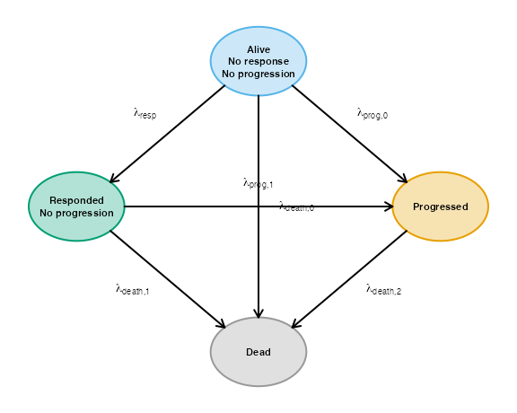

```r
# --- Illness-death model diagram ---
par(mar = c(0, 0, 0, 0))
plot.new()
plot.window(xlim = c(0, 1), ylim = c(0, 1))

# State positions (diamond layout)
sx <- c(0.50, 0.12, 0.88, 0.50)  # State 0, 1, 2, 3
sy <- c(0.88, 0.50, 0.50, 0.12)
r <- 0.10  # circle radius in user coords

# Draw state circles
theta <- seq(0, 2 * pi, length.out = 100)
state_colors <- c("#56B4E9", "#009E73", "#E69F00", "#999999")
state_labels <- c(
  "Alive\nNo response\nNo progression",
  "Responded\nNo progression",
  "Progressed",
  "Dead"
)

for (i in 1:4) {
  polygon(sx[i] + r * cos(theta), sy[i] + r * 0.9 * sin(theta),
          col = adjustcolor(state_colors[i], alpha.f = 0.3),
          border = state_colors[i], lwd = 2)
  text(sx[i], sy[i], state_labels[i], cex = 0.7, font = 2)
}

# Arrow helper: draw from edge of circle i to edge of circle j
draw_trans <- function(i, j, label_expr, label_pos = 0.5,
                       label_offset = c(0, 0), curve = 0, ...) {
  dx <- sx[j] - sx[i]
  dy <- sy[j] - sy[i]
  ang <- atan2(dy, dx)

  # Start and end at circle edge
  x0 <- sx[i] + r * cos(ang)
  y0 <- sy[i] + r * 0.9 * sin(ang)
  x1 <- sx[j] - r * cos(ang)
  y1 <- sy[j] - r * 0.9 * sin(ang)

  if (curve == 0) {
    arrows(x0, y0, x1, y1, length = 0.10, lwd = 2, ...)
    lx <- x0 + label_pos * (x1 - x0) + label_offset[1]
    ly <- y0 + label_pos * (y1 - y0) + label_offset[2]
  } else {
    # Curved arrow using xspline
    mx <- (x0 + x1) / 2 + curve * (y1 - y0)
    my <- (y0 + y1) / 2 - curve * (x1 - x0)
    xspline(c(x0, mx, x1), c(y0, my, y1), shape = c(0, 1, 0),
            border = "black", lwd = 2, ...)
    # Arrowhead at end
    ang2 <- atan2(y1 - my, x1 - mx)
    arrows(x1 - 0.01 * cos(ang2), y1 - 0.01 * sin(ang2),
           x1, y1, length = 0.10, lwd = 2, ...)
    lx <- mx + label_offset[1]
    ly <- my + label_offset[2]
  }
  text(lx, ly, label_expr, cex = 0.85)
}

# Transitions
draw_trans(1, 2, expression(lambda[resp]), label_pos = 0.45, label_offset = c(-0.06, 0.04))
draw_trans(1, 3, expression(lambda["prog,0"]), label_pos = 0.45, label_offset = c(0.06, 0.04))
draw_trans(1, 4, expression(lambda["death,0"]), label_pos = 0.5, label_offset = c(0.08, 0))
draw_trans(2, 3, expression(lambda["prog,1"]), label_pos = 0.5, label_offset = c(0, 0.06))
draw_trans(2, 4, expression(lambda["death,1"]), label_pos = 0.45, label_offset = c(-0.06, -0.04))
draw_trans(3, 4, expression(lambda["death,2"]), label_pos = 0.45, label_offset = c(0.06, -0.04))
```

```r
source(file.path(rprojroot::find_root("DESCRIPTION"), "inst", "simulation", "sim_illness_death.R"))
source(file.path(rprojroot::find_root("DESCRIPTION"), "inst", "simulation", "cut_illness_death.R"))
```

### Transition rates

Transition rates are calibrated from the design assumptions. Control arm medians are matched numerically; experimental arm rates are derived by scaling with the specified HRs and solving for the target ORR.

```r
transition_rate <- build_transition_rates(
  strata = c("BM+", "BM-"),
  treatments = c("control", "experimental"),
  median_pfs = c("BM+" = pfsmedian, "BM-" = pfsmedian),
  median_os = c("BM+" = osmedian, "BM-" = osmedian),
  orr = list(
    "BM+" = c(control = orr_ctrl_bm_pos, experimental = orr_exp_bm_pos),
    "BM-" = c(control = orr_ctrl_bm_neg, experimental = orr_exp_bm_neg)
  ),
  hr_pfs = c("BM+" = 0.70, "BM-" = 0.90),
  hr_os = c("BM+" = 0.65, "BM-" = 0.85)
)

kable(transition_rate, digits = 4, caption = "Illness-death transition rates") %>%
  kable_styling()
```

Illness-death transition rates

| stratum | treatment | transition | rate | duration |
| --- | --- | --- | --- | --- |
| BM+ | control | response | 0.0646 | Inf |
| BM+ | control | prog_0 | 0.1308 | Inf |
| BM+ | control | death_0 | 0.0200 | Inf |
| BM+ | control | prog_1 | 0.0654 | Inf |
| BM+ | control | death_1 | 0.0100 | Inf |
| BM+ | control | death_2 | 0.1263 | Inf |
| BM+ | experimental | response | 0.0855 | Inf |
| BM+ | experimental | prog_0 | 0.0915 | Inf |
| BM+ | experimental | death_0 | 0.0130 | Inf |
| BM+ | experimental | prog_1 | 0.0458 | Inf |
| BM+ | experimental | death_1 | 0.0065 | Inf |
| BM+ | experimental | death_2 | 0.0821 | Inf |
| BM- | control | response | 0.0364 | Inf |
| BM- | control | prog_0 | 0.1256 | Inf |
| BM- | control | death_0 | 0.0200 | Inf |
| BM- | control | prog_1 | 0.0628 | Inf |
| BM- | control | death_1 | 0.0100 | Inf |
| BM- | control | death_2 | 0.1223 | Inf |
| BM- | experimental | response | 0.0411 | Inf |
| BM- | experimental | prog_0 | 0.1130 | Inf |
| BM- | experimental | death_0 | 0.0170 | Inf |
| BM- | experimental | prog_1 | 0.0565 | Inf |
| BM- | experimental | death_1 | 0.0085 | Inf |
| BM- | experimental | death_2 | 0.1039 | Inf |

### Simulate one trial

```r
set.seed(20250313)
n_per_arm <- ceiling(n_bm_pos + n_bm_neg)
n_sim <- n_per_arm * 2
steady_rate <- n_sim / 11  # 14-month enrollment: 0.25*2 + 0.5*2 + 0.75*2 + 1*8 = 11 rate-months

sim_data <- sim_illness_death(
  n = n_sim,
  stratum = data.frame(stratum = c("BM+", "BM-"), p = c(bm_prev, 1 - bm_prev)),
  block = c("control", "control", "experimental", "experimental"),
  enroll_rate = data.frame(
    rate = steady_rate * c(0.25, 0.50, 0.75, 1.00),
    duration = c(2, 2, 2, 8)
  ),
  transition_rate = transition_rate,
  dropout_rate = 0.001
)

fpe <- max(sim_data$ENRLTIME)
cat("Total N:", nrow(sim_data), "\n")
```

```
#> Total N: 1306
```

```r
cat("N BM+:", sum(sim_data$STRATUM == "BM+"),
    "N BM-:", sum(sim_data$STRATUM == "BM-"), "\n")
```

```
#> N BM+: 791 N BM-: 515
```

```r
cat("FPE:", round(fpe, 1), "months\n")
```

```
#> FPE: 14.3 months
```

### Determine analysis cut dates

```r
# Extract target event counts from designs
target_pfs_events_sub <- ceiling(max(pfssub$analysis$event))
target_os_events_sub <- ceiling(max(ossub$analysis$event))

analyses <- list(
  list(min_followup = 6, endpoint = NULL, event_target = NULL,
       target_stratum = NULL, max_followup = NULL),
  list(min_followup = 14, endpoint = "PFS", event_target = target_pfs_events_sub,
       target_stratum = "BM+", max_followup = 17),
  list(min_followup = 24, endpoint = "OS", event_target = target_os_events_sub,
       target_stratum = "BM+", max_followup = 30)
)

cut_dates <- get_analysis_dates(sim_data, analyses)

cat("Analysis cut dates:\n")
```

```
#> Analysis cut dates:
```

```r
for (i in seq_along(cut_dates)) {
  cat(sprintf("  Analysis %d: %.1f months (FPE + %.1f)\n",
              i, cut_dates[i], cut_dates[i] - fpe))
}
```

```
#>   Analysis 1: 20.3 months (FPE + 6.0)
#>   Analysis 2: 28.3 months (FPE + 14.0)
#>   Analysis 3: 38.3 months (FPE + 24.0)
```

### Cut data and compute event counts

```r
adtte <- lapply(seq_along(cut_dates), function(i) {
  d <- cut_illness_death(sim_data, cut_dates[i])
  d$ANALYSIS <- i
  d
})
names(adtte) <- paste0("IA", seq_along(cut_dates))

# Event counts per analysis
event_summary <- do.call(rbind, lapply(seq_along(adtte), function(i) {
  adtte[[i]] %>%
    filter(PARAMCD %in% c("OS", "PFS")) %>%
    group_by(PARAMCD, STRATUM) %>%
    summarise(events = sum(CNSR == 0), .groups = "drop") %>%
    mutate(Analysis = i)
}))

kable(event_summary %>% tidyr::pivot_wider(
  names_from = Analysis, values_from = events, names_prefix = "Analysis "
), caption = "Event counts by analysis") %>%
  kable_styling()
```

Event counts by analysis

| PARAMCD | STRATUM | Analysis 1 | Analysis 2 | Analysis 3 |
| --- | --- | --- | --- | --- |
| OS | BM+ | 317 | 495 | 627 |
| OS | BM- | 220 | 338 | 431 |
| PFS | BM+ | 531 | 660 | 714 |
| PFS | BM- | 375 | 447 | 484 |

### Compute nominal p-values

One-sided p-values from Cox regression (OS, PFS) and rate difference test (ORR).

```r
# Helper: 1-sided p-value from Cox model (H1: HR < 1)
cox_pval <- function(data, stratified = FALSE) {
  data$event <- 1L - data$CNSR
  data$trt01 <- as.integer(data$TRT == "experimental")
  if (stratified) {
    fit <- coxph(Surv(AVAL, event) ~ trt01 + strata(STRATUM), data = data)
  } else {
    fit <- coxph(Surv(AVAL, event) ~ trt01, data = data)
  }
  z <- coef(fit) / sqrt(vcov(fit)[1, 1])
  pnorm(z)  # 1-sided: P(HR < 1)
}

# Helper: 1-sided p-value for rate difference (H1: p_exp > p_ctrl)
rd_pval <- function(data) {
  n_exp <- sum(data$TRT == "experimental")
  n_ctrl <- sum(data$TRT == "control")
  resp_exp <- sum(data$AVAL[data$TRT == "experimental"])
  resp_ctrl <- sum(data$AVAL[data$TRT == "control"])
  p_exp <- resp_exp / n_exp
  p_ctrl <- resp_ctrl / n_ctrl
  p_pool <- (resp_exp + resp_ctrl) / (n_exp + n_ctrl)
  se <- sqrt(p_pool * (1 - p_pool) * (1 / n_exp + 1 / n_ctrl))
  if (se == 0) return(0.5)
  z <- (p_exp - p_ctrl) / se
  pnorm(-z)  # 1-sided: small when experimental is better
}
```

```r
# Compute p-values for each hypothesis at each analysis
pvals <- list()

for (i in seq_along(cut_dates)) {
  d <- adtte[[i]]

  # H1: OS BM+ (analyses 1-3)
  pvals[[paste0("H1_", i)]] <- cox_pval(d %>% filter(PARAMCD == "OS", STRATUM == "BM+"))

  # H2: OS Overall (analyses 1-3)
  pvals[[paste0("H2_", i)]] <- cox_pval(d %>% filter(PARAMCD == "OS"), stratified = TRUE)

  # H3: PFS BM+ (analyses 1-2)
  if (i <= 2) {
    pvals[[paste0("H3_", i)]] <- cox_pval(d %>% filter(PARAMCD == "PFS", STRATUM == "BM+"))
  }

  # H4: PFS Overall (analyses 1-2)
  if (i <= 2) {
    pvals[[paste0("H4_", i)]] <- cox_pval(d %>% filter(PARAMCD == "PFS"), stratified = TRUE)
  }

  # H5: ORR BM+ (analysis 1 only)
  if (i == 1) {
    pvals[[paste0("H5_", i)]] <- rd_pval(d %>% filter(PARAMCD == "ORR", STRATUM == "BM+"))
  }

  # H6: ORR Overall (analysis 1 only)
  if (i == 1) {
    pvals[[paste0("H6_", i)]] <- rd_pval(d %>% filter(PARAMCD == "ORR"))
  }
}
```

### Build results table

Assemble event counts and p-values into the format required for sequential testing. Spending time uses the BM+ information fraction for all hypotheses.

```r
# Extract event counts from ADTTE
get_events <- function(analysis_idx, paramcd, stratum = NULL) {
  d <- adtte[[analysis_idx]]
  if (!is.null(stratum)) d <- d %>% filter(STRATUM == stratum)
  sum(d$PARAMCD == paramcd & d$CNSR == 0, na.rm = TRUE)
}

events_os_sub <- sapply(1:3, function(i) get_events(i, "OS", "BM+"))
events_os_all <- sapply(1:3, function(i) get_events(i, "OS"))
events_pfs_sub <- sapply(1:2, function(i) get_events(i, "PFS", "BM+"))
events_pfs_all <- sapply(1:2, function(i) get_events(i, "PFS"))

inputResults <- tibble(
  H = c(rep(1, 3), rep(2, 3), rep(3, 2), rep(4, 2), 5, 6),
  Pop = c(
    rep("BM+", 3), rep("Overall", 3),
    rep("BM+", 2), rep("Overall", 2),
    "BM+", "Overall"
  ),
  Endpoint = c(rep("OS", 6), rep("PFS", 4), rep("ORR", 2)),
  nominalP = c(
    pvals$H1_1, pvals$H1_2, pvals$H1_3,
    pvals$H2_1, pvals$H2_2, pvals$H2_3,
    pvals$H3_1, pvals$H3_2,
    pvals$H4_1, pvals$H4_2,
    pvals$H5_1,
    pvals$H6_1
  ),
  Analysis = c(1:3, 1:3, 1:2, 1:2, 1, 1),
  events = c(events_os_sub, events_os_all, events_pfs_sub, events_pfs_all, NA, NA),
  spendingTime = c(
    events_os_sub / max(events_os_sub),
    events_os_sub / max(events_os_sub),
    events_pfs_sub / max(events_pfs_sub),
    events_pfs_sub / max(events_pfs_sub),
    NA, NA
  )
)
kable(inputResults, caption = "Results from simulated trial data") %>%
  kable_styling()
```

Results from simulated trial data

| H | Pop | Endpoint | nominalP | Analysis | events | spendingTime |
| --- | --- | --- | --- | --- | --- | --- |
| 1 | BM+ | OS | 0.0000001 | 1 | 317 | 0.5055821 |
| 1 | BM+ | OS | 0.0000000 | 2 | 495 | 0.7894737 |
| 1 | BM+ | OS | 0.0000000 | 3 | 627 | 1.0000000 |
| 2 | Overall | OS | 0.0000395 | 1 | 537 | 0.5055821 |
| 2 | Overall | OS | 0.0000004 | 2 | 833 | 0.7894737 |
| 2 | Overall | OS | 0.0000000 | 3 | 1058 | 1.0000000 |
| 3 | BM+ | PFS | 0.0000052 | 1 | 531 | 0.8045455 |
| 3 | BM+ | PFS | 0.0000019 | 2 | 660 | 1.0000000 |
| 4 | Overall | PFS | 0.0004097 | 1 | 906 | 0.8045455 |
| 4 | Overall | PFS | 0.0001082 | 2 | 1107 | 1.0000000 |
| 5 | BM+ | ORR | 0.0024467 | 1 | NA | NA |
| 6 | Overall | ORR | 0.0055936 | 1 | NA | NA |

## Testing hypotheses

### Compute sequential p-values for each hypothesis

```r
### USER SHOULD NOT NEED TO MODIFY THIS CODE
EOCtab <- NULL
EOCtab <- inputResults %>%
  group_by(H) %>%
  slice(1) %>%
  ungroup() %>%
  select("H", "Pop", "Endpoint", "nominalP")
EOCtab$seqp <- .9999
for (EOCtabline in 1:nHypotheses) {
  EOCtab$seqp[EOCtabline] <-
    ifelse(is.null(gsD2list[[EOCtabline]]), EOCtab$nominalP[EOCtabline], {
      tem <- filter(inputResults, H == EOCtabline)
      gsDesign2::sequential_pval(
        gs_design = gsD2list[[EOCtabline]],
        event = tem$events,
        z = -stats::qnorm(tem$nominalP),
        ustime = tem$spendingTime,
        interval = c(1e-05, 0.9999)
      )
    })
}
EOCtab <- EOCtab %>% select(-"nominalP")
```

### Evaluate hypothesis rejection using graphicalMCP

```r
library(graphicalMCP)

g0 <- graphicalMCP::graph_create(
  hypotheses = alphaHypotheses / fwer,
  transitions = m,
  hyp_names = nameHypotheses
)
```

```r
result <- graphicalMCP::graph_test_shortcut(
  graph = g0,
  p = EOCtab$seqp,
  alpha = fwer,
  verbose = TRUE
)

adj_p <- result$outputs$adjusted_p
rej <- result$outputs$rejected

if (is.numeric(rej)) {
  rej_logical <- rep(FALSE, nHypotheses)
  rej_logical[rej] <- TRUE
} else {
  rej_logical <- as.logical(rej)
}

EOCtab$Rejected <- rej_logical
EOCtab$adjPValues <- adj_p
```

## Verification of hypotheses rejected

```r
rejected_order <- which(EOCtab$Rejected)[order(EOCtab$adjPValues[EOCtab$Rejected])]

graphs <- list(g0)
if (length(rejected_order) > 0) {
  gu <- graphicalMCP::graph_update(g0, delete = rejected_order)
  graphs <- gu$intermediate_graphs
}
ngraphs <- length(graphs)

lastWeights <- as.numeric(graphs[[ngraphs]]$hypotheses)
lastGraph <- rep(ngraphs, nrow(EOCtab))

if (length(rejected_order) > 0) {
  for (j in seq_along(rejected_order)) {
    h <- rejected_order[j]
    lastWeights[h] <- as.numeric(graphs[[j]]$hypotheses[h])
    lastGraph[h] <- j
  }
}

EOCtab$lastAlpha <- fwer * lastWeights
EOCtab$lastGraph <- lastGraph
EOCtabx <- EOCtab
names(EOCtabx) <- c(
  "Hypothesis", "Population", "Endpoint", "Sequential p",
  "Rejected", "Adjusted p", "Max alpha allocated", "Last Graph"
)
```

### Multiplicity graph sequence from graphicalMCP

```r
### THERE SHOULD BE NO NEED TO MODIFY THIS CODE SECTION
for (i in 1:ngraphs) {
  cat(" \n")
  cat("####", paste(" Graph", as.character(i), " \n\n"))
  gi_alpha <- fwer * as.numeric(graphs[[i]]$hypotheses)
  gi_labels <- paste(
    names(graphs[[i]]$hypotheses),
    sprintf("\u03b1 = %s", format(gi_alpha, scientific = FALSE)),
    sep = "\n"
  )
  plot(graphs[[i]],
    layout = layout6,
    vertex.size = 45,
    vertex.label = gi_labels,
    vertex.label.cex = 0.9,
    vertex.color = unname(vertex_color_map[names(graphs[[i]]$hypotheses)]),
    margin = 0.25
  )
  cat(" \n\n\n")
}
```

#### Graph 1

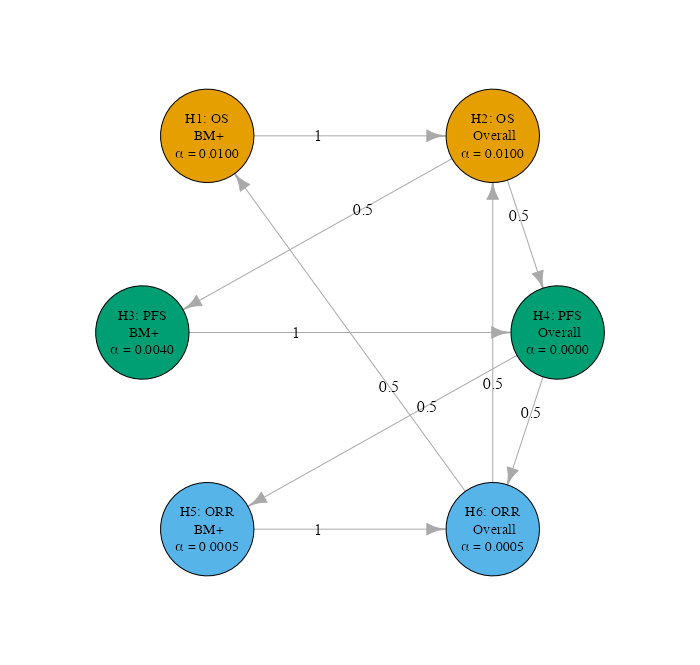

#### Graph 2

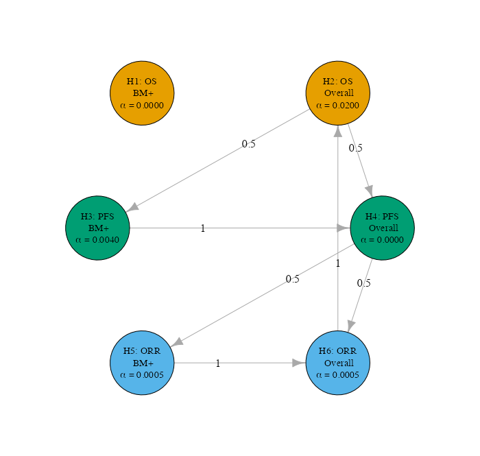

#### Graph 3

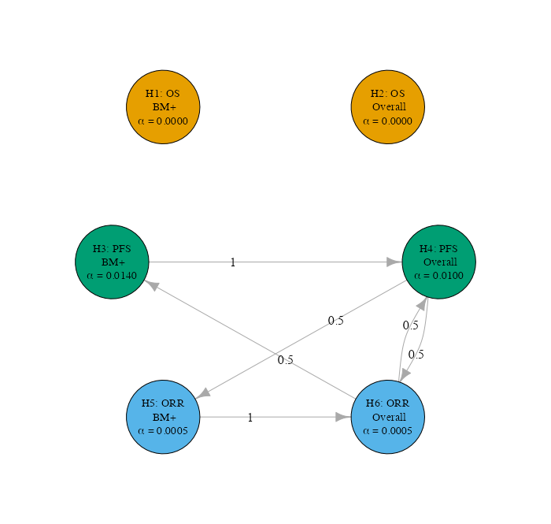

#### Graph 4

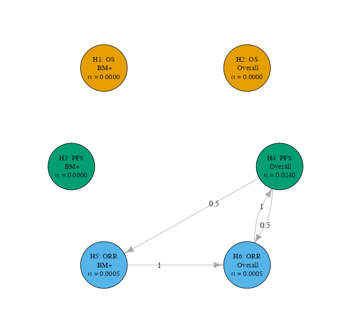

#### Graph 5

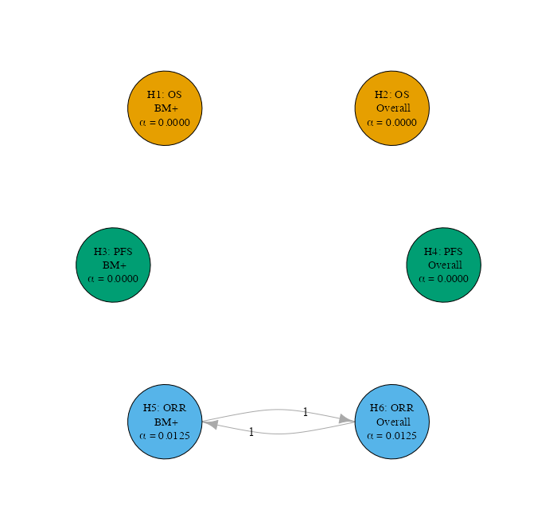

#### Graph 6

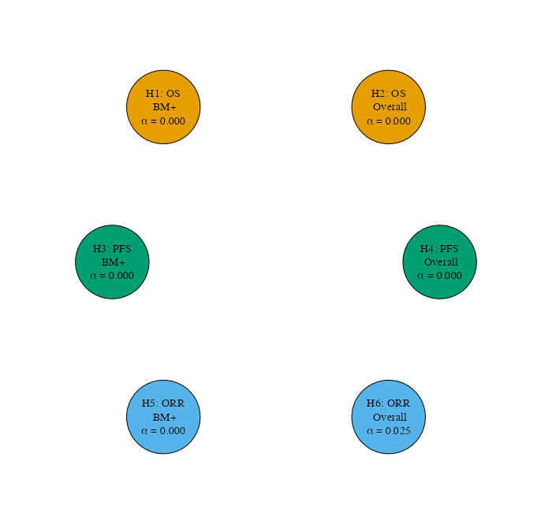

#### Graph 7

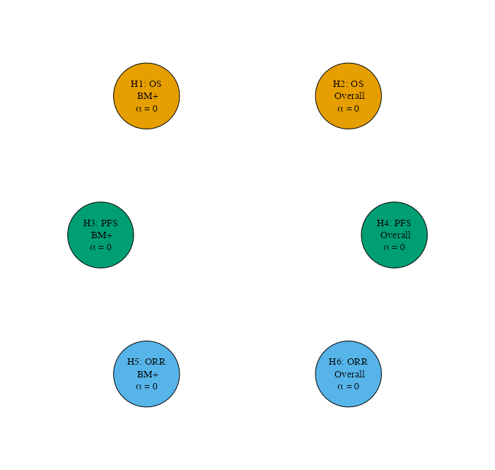

### Comparison of sequential p-values to multiplicity graphs

```r
EOCtabx %>%
  select(c(1:4, 7, 5:6, 8)) %>%
  kable() %>%
  kable_styling()
```

| Hypothesis | Population | Endpoint | Sequential p | Max alpha allocated | Rejected | Adjusted p | Last Graph |
| --- | --- | --- | --- | --- | --- | --- | --- |
| 1 | BM+ | OS | 0.0000100 | 0.0100 | TRUE | 0.0000250 | 1 |
| 2 | Overall | OS | 0.0000100 | 0.0200 | TRUE | 0.0000250 | 2 |
| 3 | BM+ | PFS | 0.0000100 | 0.0140 | TRUE | 0.0000250 | 3 |
| 4 | Overall | PFS | 0.0001132 | 0.0240 | TRUE | 0.0001179 | 4 |
| 5 | BM+ | ORR | 0.0024467 | 0.0125 | TRUE | 0.0048934 | 5 |
| 6 | Overall | ORR | 0.0055936 | 0.0250 | TRUE | 0.0055936 | 6 |

### Bounds at final alpha allocated for group sequential tests

```r
for (i in 1:nHypotheses) {
  cat("####", paste(" Hypothesis", as.character(i), " \n"))
  hresults <- inputResults %>% filter(H == i)
  xx <- paste("Max alpha allocated from above table: ",
    as.character(EOCtab$lastAlpha[i]),
    sep = ""
  )
  d2 <- gsD2list[[i]]
  if (is.null(d2)) {
    cat("Maximum alpha allocated: ")
    cat(EOCtab$lastAlpha[i])
    cat("\n\n")
    cat("Nominal p-value for hypothesis test: ")
    cat(hresults$nominalP)
    cat("\n\n")
  }
  if (!is.null(gsD2list[[i]])) {
    cat("Nominal p-values at each analysis for comparison to bounds in table below:\n\n")
    cat(hresults$nominalP)
    cat("\n\n")
    n.I <- hresults$events
    usTime <- hresults$spendingTime
    if (EOCtab$lastAlpha[i] == 0) {
      cat("Maximum alpha allocated: 0\n\n")
      cat("No testing required\n\n")
    }
    if (EOCtab$lastAlpha[i] > 0) {
      d2_upd <- gsDesign2::gs_update_ahr(
        x = d2,
        alpha = EOCtab$lastAlpha[i],
        ustime = usTime,
        event_tbl = data.frame(analysis = hresults$Analysis, event = n.I)
      )

      d2_upd$bound %>%
        dplyr::filter(.data$bound == "upper") %>%
        dplyr::left_join(
          data.frame(analysis = hresults$Analysis, spending_time = usTime),
          by = "analysis"
        ) %>%
        dplyr::transmute(
          Analysis = .data$analysis,
          Z = .data$z,
          `Nominal p (1-sided)` = .data$`nominal p`,
          `Spending time` = .data$spending_time
        ) %>%
        kable(caption = xx, row.names = FALSE) %>%
        kable_styling() %>%
        cat()
      cat("\n\n")
    }
  }
}
```

#### Hypothesis 1

Nominal p-values at each analysis for comparison to bounds in table below:

0.00000008604815 0.0000000002351157 0.000000000003306387

Max alpha allocated from above table: 0.01

| Analysis | Z | Nominal p (1-sided) | Spending time |
| --- | --- | --- | --- |
| 1 | 3.439264 | 0.0002916 | 0.5055821 |
| 2 | 2.683207 | 0.0036460 | 0.7894737 |
| 3 | 2.372121 | 0.0088432 | 1.0000000 |

#### Hypothesis 2

Nominal p-values at each analysis for comparison to bounds in table below:

0.00003950852 0.0000003579727 0.00000002792801

Max alpha allocated from above table: 0.02

| Analysis | Z | Nominal p (1-sided) | Spending time |
| --- | --- | --- | --- |
| 1 | 3.070395 | 0.0010689 | 0.5055821 |
| 2 | 2.386769 | 0.0084986 | 0.7894737 |
| 3 | 2.113828 | 0.0172650 | 1.0000000 |

#### Hypothesis 3

Nominal p-values at each analysis for comparison to bounds in table below:

0.000005161198 0.000001936512

Max alpha allocated from above table: 0.014

| Analysis | Z | Nominal p (1-sided) | Spending time |
| --- | --- | --- | --- |
| 1 | 2.503265 | 0.0061527 | 0.8045455 |
| 2 | 2.251570 | 0.0121747 | 1.0000000 |

#### Hypothesis 4

Nominal p-values at each analysis for comparison to bounds in table below:

0.0004097233 0.000108211

Max alpha allocated from above table: 0.024

| Analysis | Z | Nominal p (1-sided) | Spending time |
| --- | --- | --- | --- |
| 1 | 2.261771 | 0.0118558 | 0.8045455 |
| 2 | 2.037430 | 0.0208035 | 1.0000000 |

#### Hypothesis 5

Maximum alpha allocated: 0.0125

Nominal p-value for hypothesis test: 0.002446689

#### Hypothesis 6

Maximum alpha allocated: 0.025

Nominal p-value for hypothesis test: 0.005593569

```r
options(old)
```

## Session information

You can use `sessionInfo()` to document the versions of R and R packages used to render this document.